# Composition of peripheral blood immune cell compartment in stage 5 chronic kidney disease is affected by smoking and other risk factors associated with systemic inflammatory response

**Authors and affiliations**:

Ivan Zahradka<sup>1</sup>, Filip Tichanek<sup>2</sup>, Lucie Majercikova<sup>3</sup>, Jana Douskova<sup>3</sup>, Mathias Streitz<sup>4</sup>, Stephan Schlickeiser<sup>5,6</sup>, Klara Osickova<sup>1</sup>, Vojtech Petr<sup>1</sup>, Petra Hruba<sup>3</sup>, Petra Reinke<sup>7</sup>, Ondrej Viklicky<sup>1,3</sup>

<sup>1</sup> Department of Nephrology, Institute for Clinical and Experimental Medicine, Czech Republic  
<sup>2</sup> Department of Data Science, Institute for Clinical and Experimental Medicine, Czech Republic  
<sup>3</sup> Transplantation Laboratory, Institute for Clinical and Experimental Medicine, Prague, Czech Republic  
<sup>4</sup> Department of Experimental Animal Facilities and Biorisk Management, Federal Research Institute for Animal Health, Greifswald-Insel Riems, Germany  
<sup>5</sup> Berlin Institute of Health Center of Regenerative Therapies (BRCT), Berlin Institute of Health at Charité, Berlin, Germany  
<sup>6</sup> CheckImmune GmbH, Campus Virchow Klinikum, Berlin, Germany  
<sup>7</sup> Center for Advanced Therapies (BeCAT), Charité Universitätsmedizin, Berlin, Germany

This is a statistical report of the [study](https://doi.org/10.3389/fimmu.2025.1608206) *Composition of peripheral blood immune cell compartment in stage 5 chronic kidney disease is affected by smoking and other risk factors associated with systemic inflammatory response* published in the [Frontiers in Immunulogy](https://www.frontiersin.org/journals/immunology)

When using this code or data, cite the original publication:

> Zahradka I, Tichanek F, Majercikova L, Duskova J, Streitz M, Schlickeiser S, Osickova K, Petr V, Hruba P, Reinke P and Viklicky O (2025) Composition of peripheral blood immune cell compartment in stage 5 chronic kidney disease is affected by smoking and other risk factors associated with systemic inflammatory response. Front. Immunol. 16:1608206. doi: 10.3389/fimmu.2025.1608206

Original [GitHub repository](https://github.com/filip-tichanek/rTX_lymphocytes)

**Statistical code** with all details of statistical analysis is shown a [HTML report](https://filip-tichanek.github.io/rTX_lymphocytes/).

Original **data** are available [here](https://github.com/filip-tichanek/rTX_lymphocytes/blob/main/data_all.csv)

# 1 Introduction

## 1.1 Statistical methodology

All analyses were run in R, version 4.1 (R Core Team 2024).

Initially, we noted that only 3 patients had repeated renal transplantation. Their lymphocyte counts were noticeably different from other patients, so we excluded these re-transplanted patients from all analyses.

Predictors (clinical characteristics) that showed a statistically significant effect in any of the multivariable PERMANOVAs were then used in a series of generalized linear models, fitted with ‘glmmTMB’ package (Brooks et al. 2017). Although variable selection for these PERMANOVAs was primarily based on $R^2$, the same set of covariates would have been selected if PERMANOVA variable selection had been based on p-values < 0.05. These models predicted the count of a specific lymphocyte sub-population assuming a Poisson distribution, with observation-specific random intercepts to account for overdispersion. The selected predictors were: Smoking, cmv (past Cytomegalovirus infection), receiver_age_30y (receiver age scaled so that a 30-year increase represents a one-unit change), Dialysis, and ascvd (Atherosclerotic Cardiovascular Disease). P-values for each predictor were corrected using the Benjamini-Hochberg correction (FDR) for multiple comparisons (Benjamini and Hochberg 1995), accounting for the repeated estimation of the effect of each predictor across 18 lymphocyte sub-populations. The results were visualized using a volcano plot, showing the estimated effect of the predictor on the X axis (as estimated log-fold difference in count when the predictor value increases by 1 unit) and the -log10(P-value) on the Y axis (the higher the value, the stronger the evidence of the effect direction). As a sensitivity analysis, we repeated the same procedure using linear model with log-transformed counts.

# 2 Analysis

## 2.1 Initialization

### 2.1.1 Packages

```r
if (TRUE) {rm(list = ls() )}
if (TRUE) {
  suppressWarnings(suppressMessages({
    library(tidyverse)
    library(stringr)
    library(stringi)
    library(ggpubr)
    library(emmeans)
    library(gtsummary)
    library(car)
    library(RJDBC)
    library(sjPlot)
    library(flextable)
    library(openxlsx)
    library(mgcv)
    library(pROC)
    library(cowplot)
    library(boot)
    library(glmnet)
    library(brms)
    library(janitor)
    library(arm)
    library(corrplot)
    library(lubridate)
    library(kableExtra)
    library(ggdist)
    library(bayesplot)
    library(coxed)
    library(quantreg)
    library(ggbeeswarm)
    library(vegan)
    library(circlize)
    library(ComplexHeatmap)
    library(glmmTMB)
    library(ggrepel)
  }))
}
```

### 2.1.2 Functions

```r
setwd('~/1_ticf_sec/483_ZAHI_lymphocytes')
source('483_functions.R')
```

### 2.1.3 Directories

```r
folders <- c("data",
             "gitignore",
             "gitignore/run",
             "gitignore/figures",
             "gitignore/outputs",
             "gitignore/data")

invisible(
  lapply(folders, function(x) if (!dir.exists(x))
    dir.create(x, recursive = TRUE)
    )
  )
```

### 2.1.4 Seed

```r
set.seed(16)
```

## 2.2 Data

### 2.2.1 Import and wrangling

Import

```r
if (!file.exists("data/data_all.csv")) {
  data_excel_all <- read.xlsx("gitignore/data/FACS_lymfocyty_filip2.xlsx") %>%
    dplyr::mutate(
      id = as.character(1:nrow(.)),
      group = factor(group)
    ) %>%
    dplyr::rename(
    `non_switched_memory` = `non-switched.memory`) %>%
    dplyr::select(
      -`rodne_cislo`, -`Jmeno`,
      -`Sekce.klinické.proměnné`,
      -`sekce.dendritické.buňky`,
      -`sekce.B-lymfocyty`,
      -`Sekce.T-lymfocyty`
    ) %>%
    dplyr::select(id, everything())

  readr::write_csv(data_excel_all, "data/data_all.csv")
}

data_excel_all <- readr::read_csv("data/data_all.csv") %>%
  mutate(group = factor(group),
         id = as.character(id))
## Rows: 136 Columns: 40
## ── Column specification ────────────────────────────────────────────────────────
## Delimiter: ","
## chr  (1): group
## dbl (39): id, Diabetes, PRD.GN, Smoking, hep.B, ASCVD, lecena.hypertenze, le...
##
## ℹ Use `spec()` to retrieve the full column specification for this data.
## ℹ Specify the column types or set `show_col_types = FALSE` to quiet this message.


data_avail <- data_excel_all %>%
  dplyr::rename(
    mDC1 = mDC1_absp,
    mDC2 = mDC2_absp,
    mDC3 = mDC3_absp,
    pDC = pDC_absp,
    `naive B cells` = naiveB_absp,
    `marginal-zone B cells` = marginal.B,
    `class non-switched memory cells` = `non_switched_memory`,
    `class switched memory cells` = switched.memory,
    plasmablast = Plazmablasty_absp,
    `transitional B cells` = Transitional_absp,
    `CD4+ CM cells` = CD.4.CM,
    `CD4+ EM cells` = CD.4.EM,
    `CD4+ naive cells` = CD4_naive_absp,
    `CD4+ TEMRA cells` = CD4_TEMRA_absp,
    `CD8+ CM cells` = CD8_CM_absp,
    `CD8+ EM cells` = CD8_EM_absp,
    `CD8+ naive cells` = CD.8.naive,
    `CD8+ TEMRA cells` = CD8_TEMRA_absp,
    mDC1 = mDC1_absp,
    mDC2 = mDC2_absp,
    mDC3 = mDC3_absp,
    pDC = pDC_absp,
    `naive B cells` = naiveB_absp,
    `marginal-zone B cells` = marginal.B,
    `HLA-DR+ cells`= `HLA_DR+_Absp`,
     `total mDC` = `mDC_absp`,
     `total CD19+ B cells` = `CD.19`,
     `total CD3+ cells` = `CD3_absp`,
     `total CD4+ cells` = `CD4_absp`,
     `total CD8+ cells` = `CD8_absp`,
     `diabetes` = `Diabetes`,
    `hepatitis_b` = `hep.B`,
    `hypertension` = `lecena.hypertenze`,
    `hyperuricemia` = `lecena.hyperurikemie`,
    `dyslipidemia` = `lecena.dyslipidemie`,
    `anti_HLA` = `anti-HLA.preTx.nebo.historicky.ano/ne`,
    `receiver_age` = `věk.příjemce`,
    `receiver_female` = `pohlavi.prijemce.(ž=1)`,
    `dialysis` = `Dialysis`,
    `re_transplantation` = `retransplantace`)

skimr::skim(data_avail)
```

Data summary

| Name | data_avail |
| --- | --- |
| Number of rows | 136 |
| Number of columns | 40 |
| _______________________ |  |
| Column type frequency: |  |
| character | 1 |
| factor | 1 |
| numeric | 38 |
| ________________________ |  |
| Group variables | None |

**Variable type: character**

| skim_variable | n_missing | complete_rate | min | max | empty | n_unique | whitespace |
| --- | --- | --- | --- | --- | --- | --- | --- |
| id | 0 | 1 | 1 | 3 | 0 | 136 | 0 |

**Variable type: factor**

| skim_variable | n_missing | complete_rate | ordered | n_unique | top_counts |
| --- | --- | --- | --- | --- | --- |
| group | 0 | 1 | FALSE | 2 | pat: 107, con: 29 |

**Variable type: numeric**

| skim_variable | n_missing | complete_rate | mean | sd | p0 | p25 | p50 | p75 | p100 | hist |
| --- | --- | --- | --- | --- | --- | --- | --- | --- | --- | --- |
| diabetes | 29 | 0.79 | 0.21 | 0.41 | 0.00 | 0.00 | 0.00 | 0.00 | 1.00 | ▇▁▁▁▂ |
| PRD.GN | 29 | 0.79 | 0.46 | 0.50 | 0.00 | 0.00 | 0.00 | 1.00 | 1.00 | ▇▁▁▁▇ |
| Smoking | 29 | 0.79 | 0.27 | 0.45 | 0.00 | 0.00 | 0.00 | 1.00 | 1.00 | ▇▁▁▁▃ |
| hepatitis_b | 29 | 0.79 | 0.04 | 0.19 | 0.00 | 0.00 | 0.00 | 0.00 | 1.00 | ▇▁▁▁▁ |
| ASCVD | 29 | 0.79 | 0.20 | 0.40 | 0.00 | 0.00 | 0.00 | 0.00 | 1.00 | ▇▁▁▁▂ |
| hypertension | 29 | 0.79 | 0.94 | 0.23 | 0.00 | 1.00 | 1.00 | 1.00 | 1.00 | ▁▁▁▁▇ |
| hyperuricemia | 29 | 0.79 | 0.42 | 0.50 | 0.00 | 0.00 | 0.00 | 1.00 | 1.00 | ▇▁▁▁▆ |
| dyslipidemia | 29 | 0.79 | 0.51 | 0.50 | 0.00 | 0.00 | 1.00 | 1.00 | 1.00 | ▇▁▁▁▇ |
| anti_HLA | 29 | 0.79 | 0.24 | 0.43 | 0.00 | 0.00 | 0.00 | 0.00 | 1.00 | ▇▁▁▁▂ |
| receiver_age | 29 | 0.79 | 50.81 | 13.12 | 18.86 | 41.76 | 53.14 | 62.18 | 80.44 | ▂▅▇▇▁ |
| receiver_female | 29 | 0.79 | 0.29 | 0.46 | 0.00 | 0.00 | 0.00 | 1.00 | 1.00 | ▇▁▁▁▃ |
| dialysis | 29 | 0.79 | 0.75 | 0.44 | 0.00 | 0.50 | 1.00 | 1.00 | 1.00 | ▃▁▁▁▇ |
| re_transplantation | 29 | 0.79 | 0.03 | 0.17 | 0.00 | 0.00 | 0.00 | 0.00 | 1.00 | ▇▁▁▁▁ |
| CMV | 29 | 0.79 | 0.81 | 0.39 | 0.00 | 1.00 | 1.00 | 1.00 | 1.00 | ▂▁▁▁▇ |
| HLA-DR+ cells | 0 | 1.00 | 69.44 | 45.68 | 2.14 | 39.75 | 57.17 | 87.68 | 263.98 | ▇▆▂▁▁ |
| total mDC | 0 | 1.00 | 54.32 | 39.33 | 0.30 | 26.43 | 46.15 | 71.87 | 198.29 | ▇▇▃▁▁ |
| mDC1 | 0 | 1.00 | 8.45 | 6.44 | 0.11 | 4.26 | 7.48 | 10.99 | 32.33 | ▇▇▂▁▁ |
| mDC2 | 0 | 1.00 | 40.12 | 32.28 | 0.10 | 16.67 | 33.05 | 55.62 | 156.81 | ▇▆▂▁▁ |
| mDC3 | 0 | 1.00 | 0.47 | 0.62 | 0.00 | 0.17 | 0.33 | 0.58 | 5.94 | ▇▁▁▁▁ |
| pDC | 0 | 1.00 | 12.81 | 17.65 | 0.50 | 4.83 | 8.11 | 13.91 | 159.52 | ▇▁▁▁▁ |
| total CD19+ B cells | 0 | 1.00 | 137.46 | 128.13 | 0.30 | 56.24 | 99.52 | 182.46 | 815.84 | ▇▂▁▁▁ |
| naive B cells | 0 | 1.00 | 79.31 | 85.00 | 0.00 | 25.77 | 55.40 | 95.69 | 564.31 | ▇▂▁▁▁ |
| marginal-zone B cells | 0 | 1.00 | 20.25 | 18.36 | 0.04 | 7.86 | 15.16 | 26.10 | 105.19 | ▇▃▁▁▁ |
| class non-switched memory cells | 0 | 1.00 | 19.59 | 21.69 | 0.00 | 5.92 | 13.75 | 25.53 | 156.59 | ▇▁▁▁▁ |
| class switched memory cells | 0 | 1.00 | 15.89 | 17.11 | 0.00 | 5.81 | 10.70 | 20.28 | 116.93 | ▇▂▁▁▁ |
| plasmablast | 0 | 1.00 | 0.83 | 1.62 | 0.00 | 0.16 | 0.41 | 0.78 | 11.61 | ▇▁▁▁▁ |
| transitional B cells | 0 | 1.00 | 10.52 | 14.63 | 0.00 | 2.38 | 6.68 | 12.57 | 125.80 | ▇▁▁▁▁ |
| total CD3+ cells | 1 | 0.99 | 1269.76 | 669.92 | 0.20 | 776.51 | 1207.49 | 1591.39 | 4492.87 | ▅▇▂▁▁ |
| total CD4+ cells | 1 | 0.99 | 750.07 | 377.31 | 0.02 | 495.59 | 704.21 | 958.30 | 2922.12 | ▆▇▁▁▁ |
| CD4+ CM cells | 1 | 0.99 | 383.01 | 228.08 | 0.00 | 251.82 | 341.99 | 508.35 | 1794.23 | ▇▆▁▁▁ |
| CD4+ EM cells | 1 | 0.99 | 96.00 | 75.20 | 0.00 | 43.19 | 75.54 | 127.54 | 444.02 | ▇▅▁▁▁ |
| CD4+ naive cells | 1 | 0.99 | 249.29 | 175.27 | 0.02 | 118.51 | 212.75 | 326.79 | 957.51 | ▇▇▂▁▁ |
| CD4+ TEMRA cells | 1 | 0.99 | 23.14 | 63.55 | 0.00 | 1.93 | 5.99 | 15.31 | 562.90 | ▇▁▁▁▁ |
| total CD8+ cells | 1 | 0.99 | 433.05 | 325.32 | 0.18 | 217.43 | 348.76 | 567.49 | 2331.76 | ▇▃▁▁▁ |
| CD8+ CM cells | 1 | 0.99 | 63.67 | 67.78 | 0.13 | 28.18 | 46.59 | 76.16 | 565.37 | ▇▁▁▁▁ |
| CD8+ EM cells | 1 | 0.99 | 97.95 | 84.91 | 0.04 | 39.55 | 80.00 | 130.53 | 495.01 | ▇▃▁▁▁ |
| CD8+ naive cells | 1 | 0.99 | 99.66 | 100.77 | 0.00 | 37.69 | 76.30 | 123.68 | 823.58 | ▇▁▁▁▁ |
| CD8+ TEMRA cells | 1 | 0.99 | 172.29 | 199.42 | 0.02 | 56.92 | 109.65 | 213.23 | 1496.27 | ▇▁▁▁▁ |

```r
names(data_avail)
##  [1] "id"                              "group"
##  [3] "diabetes"                        "PRD.GN"
##  [5] "Smoking"                         "hepatitis_b"
##  [7] "ASCVD"                           "hypertension"
##  [9] "hyperuricemia"                   "dyslipidemia"
## [11] "anti_HLA"                        "receiver_age"
## [13] "receiver_female"                 "dialysis"
## [15] "re_transplantation"              "CMV"
## [17] "HLA-DR+ cells"                   "total mDC"
## [19] "mDC1"                            "mDC2"
## [21] "mDC3"                            "pDC"
## [23] "total CD19+ B cells"             "naive B cells"
## [25] "marginal-zone B cells"           "class non-switched memory cells"
## [27] "class switched memory cells"     "plasmablast"
## [29] "transitional B cells"            "total CD3+ cells"
## [31] "total CD4+ cells"                "CD4+ CM cells"
## [33] "CD4+ EM cells"                   "CD4+ naive cells"
## [35] "CD4+ TEMRA cells"                "total CD8+ cells"
## [37] "CD8+ CM cells"                   "CD8+ EM cells"
## [39] "CD8+ naive cells"                "CD8+ TEMRA cells"

data_excel <- data_excel_all %>%
  na.omit()

dim(data_excel)
## [1] 106  40
```

Clinical data

```r
data_clinical <- data_excel %>%
  dplyr::select(
    id, Diabetes, PRD.GN, Smoking, hep.B, ASCVD,
    lecena.hypertenze, lecena.hyperurikemie, lecena.dyslipidemie,
    `anti-HLA.preTx.nebo.historicky.ano/ne`,
    `věk.příjemce`, `pohlavi.prijemce.(ž=1)`,
    Dialysis, retransplantace, CMV) %>%
  dplyr::rename(
    `diabetes` = `Diabetes`,
    `hepatitis_b` = `hep.B`,
    `hypertension` = `lecena.hypertenze`,
    `hyperuricemia` = `lecena.hyperurikemie`,
    `dyslipidemia` = `lecena.dyslipidemie`,
    `anti_HLA` = `anti-HLA.preTx.nebo.historicky.ano/ne`,
    `receiver_age` = `věk.příjemce`,
    `receiver_female` = `pohlavi.prijemce.(ž=1)`,
    `dialysis` = `Dialysis`,
    `re_transplantation` = `retransplantace`)

summary(data_clinical)
##       id               diabetes         PRD.GN          Smoking
##  Length:106         Min.   :0.000   Min.   :0.0000   Min.   :0.0000
##  Class :character   1st Qu.:0.000   1st Qu.:0.0000   1st Qu.:0.0000
##  Mode  :character   Median :0.000   Median :0.0000   Median :0.0000
##                     Mean   :0.217   Mean   :0.4528   Mean   :0.2642
##                     3rd Qu.:0.000   3rd Qu.:1.0000   3rd Qu.:1.0000
##                     Max.   :1.000   Max.   :1.0000   Max.   :1.0000
##   hepatitis_b          ASCVD         hypertension    hyperuricemia
##  Min.   :0.00000   Min.   :0.0000   Min.   :0.0000   Min.   :0.0000
##  1st Qu.:0.00000   1st Qu.:0.0000   1st Qu.:1.0000   1st Qu.:0.0000
##  Median :0.00000   Median :0.0000   Median :1.0000   Median :0.0000
##  Mean   :0.03774   Mean   :0.1981   Mean   :0.9434   Mean   :0.4245
##  3rd Qu.:0.00000   3rd Qu.:0.0000   3rd Qu.:1.0000   3rd Qu.:1.0000
##  Max.   :1.00000   Max.   :1.0000   Max.   :1.0000   Max.   :1.0000
##   dyslipidemia       anti_HLA       receiver_age   receiver_female
##  Min.   :0.0000   Min.   :0.0000   Min.   :18.86   Min.   :0.0000
##  1st Qu.:0.0000   1st Qu.:0.0000   1st Qu.:41.48   1st Qu.:0.0000
##  Median :1.0000   Median :0.0000   Median :53.33   Median :0.0000
##  Mean   :0.5094   Mean   :0.2453   Mean   :50.79   Mean   :0.2925
##  3rd Qu.:1.0000   3rd Qu.:0.0000   3rd Qu.:62.26   3rd Qu.:1.0000
##  Max.   :1.0000   Max.   :1.0000   Max.   :80.44   Max.   :1.0000
##     dialysis      re_transplantation      CMV
##  Min.   :0.0000   Min.   :0.0000     Min.   :0.0000
##  1st Qu.:0.2500   1st Qu.:0.0000     1st Qu.:1.0000
##  Median :1.0000   Median :0.0000     Median :1.0000
##  Mean   :0.7453   Mean   :0.0283     Mean   :0.8113
##  3rd Qu.:1.0000   3rd Qu.:0.0000     3rd Qu.:1.0000
##  Max.   :1.0000   Max.   :1.0000     Max.   :1.0000
```

General lymphocytes (wider lymphocytes categories)

```r
data_lymphocytes_general <- data_excel %>%
  dplyr::select(
    id, `HLA_DR+_Absp`, `mDC_absp`,
    `CD.19`, `CD3_absp`, `CD4_absp`, `CD8_absp`) %>%
    rename(
     `HLA-DR+ cells`= `HLA_DR+_Absp`,
     `total mDC` = `mDC_absp`,
     `total CD19+ B cells` = `CD.19`,
     `total CD3+ cells` = `CD3_absp`,
     `total CD4+ cells` = `CD4_absp`,
     `total CD8+ cells` = `CD8_absp`
    )

summary(data_lymphocytes_general)
##       id            HLA-DR+ cells       total mDC        total CD19+ B cells
##  Length:106         Min.   :  2.143   Min.   :  0.9969   Min.   :  0.3032
##  Class :character   1st Qu.: 41.339   1st Qu.: 31.8812   1st Qu.: 49.3718
##  Mode  :character   Median : 59.071   Median : 47.1999   Median : 83.6212
##                     Mean   : 72.969   Mean   : 59.7426   Mean   :109.3094
##                     3rd Qu.: 91.785   3rd Qu.: 74.6530   3rd Qu.:131.7112
##                     Max.   :263.984   Max.   :198.2863   Max.   :815.8440
##  total CD3+ cells total CD4+ cells total CD8+ cells
##  Min.   : 240.0   Min.   : 116.2   Min.   :  44.87
##  1st Qu.: 745.2   1st Qu.: 477.1   1st Qu.: 202.81
##  Median :1036.9   Median : 689.2   Median : 326.15
##  Mean   :1206.8   Mean   : 731.7   Mean   : 400.42
##  3rd Qu.:1515.0   3rd Qu.: 912.4   3rd Qu.: 519.38
##  Max.   :4492.9   Max.   :2922.1   Max.   :2331.76


data_lymphocytes_general_log10 <- data_lymphocytes_general %>%
  dplyr::mutate(dplyr::across(
    .cols = dplyr::where(is.numeric),
    .fns = ~ arm::rescale(log10(.x + 0.5)),
    .names = "scaled_log10_{.col}"
  )) %>%
  dplyr::select(-c(`HLA-DR+ cells` : `total CD8+ cells`))

summary(data_lymphocytes_general_log10)
##       id            scaled_log10_HLA-DR+ cells scaled_log10_total mDC
##  Length:106         Min.   :-2.33382           Min.   :-2.2848499
##  Class :character   1st Qu.:-0.27386           1st Qu.:-0.2557272
##  Mode  :character   Median :-0.01045           Median : 0.0000093
##                     Mean   : 0.00000           Mean   : 0.0000000
##                     3rd Qu.: 0.31597           3rd Qu.: 0.3000675
##                     Max.   : 1.10152           Max.   : 0.9421523
##  scaled_log10_total CD19+ B cells scaled_log10_total CD3+ cells
##  Min.   :-2.47345                 Min.   :-1.41203
##  1st Qu.:-0.23674                 1st Qu.:-0.33065
##  Median : 0.04644                 Median :-0.01514
##  Mean   : 0.00000                 Mean   : 0.00000
##  3rd Qu.: 0.29138                 3rd Qu.: 0.34719
##  Max.   : 1.27773                 Max.   : 1.38593
##  scaled_log10_total CD4+ cells scaled_log10_total CD8+ cells
##  Min.   :-1.63279              Min.   :-1.30202
##  1st Qu.:-0.28429              1st Qu.:-0.28711
##  Median : 0.06748              Median : 0.03384
##  Mean   : 0.00000              Mean   : 0.00000
##  3rd Qu.: 0.33573              3rd Qu.: 0.34833
##  Max.   : 1.44914              Max.   : 1.36410
```

Specific lymphocytes (narrower lymphocytes categories)

```r
data_lymphocytes_specific <- data_excel %>%
  dplyr::select(
    id,
    `mDC1_absp`,`mDC2_absp`, `mDC3_absp`,
    `pDC_absp`,
    `naiveB_absp`,
    `marginal.B`, `non_switched_memory`,`switched.memory`,
    `Plazmablasty_absp`,`Transitional_absp`,
    `CD.4.CM`, `CD.4.EM`, `CD4_naive_absp`, `CD4_TEMRA_absp`,
    `CD8_CM_absp`, `CD8_EM_absp`, `CD.8.naive`, `CD8_TEMRA_absp`) %>%
  dplyr::rename(
    mDC1 = mDC1_absp,
    mDC2 = mDC2_absp,
    mDC3 = mDC3_absp,
    pDC = pDC_absp,
    `naive B cells` = naiveB_absp,
    `marginal-zone B cells` = marginal.B,
    `class non-switched memory cells` = non_switched_memory,
    `class switched memory cells` = switched.memory,
    plasmablast = Plazmablasty_absp,
    `transitional B cells` = Transitional_absp,
    `CD4+ CM cells` = CD.4.CM,
    `CD4+ EM cells` = CD.4.EM,
    `CD4+ naive cells` = CD4_naive_absp,
    `CD4+ TEMRA cells` = CD4_TEMRA_absp,
    `CD8+ CM cells` = CD8_CM_absp,
    `CD8+ EM cells` = CD8_EM_absp,
    `CD8+ naive cells` = CD.8.naive,
    `CD8+ TEMRA cells` = CD8_TEMRA_absp
  )


summary(data_lymphocytes_specific)
##       id                 mDC1              mDC2               mDC3
##  Length:106         Min.   : 0.2758   Min.   :  0.4985   Min.   :0.0000
##  Class :character   1st Qu.: 4.8975   1st Qu.: 19.5353   1st Qu.:0.1776
##  Mode  :character   Median : 7.8591   Median : 35.4651   Median :0.3278
##                     Mean   : 9.1475   Mean   : 44.0277   Mean   :0.4632
##                     3rd Qu.:11.7542   3rd Qu.: 57.8292   3rd Qu.:0.6290
##                     Max.   :32.3276   Max.   :156.8147   Max.   :2.3878
##       pDC           naive B cells    marginal-zone B cells
##  Min.   :  0.5043   Min.   :  0.00   Min.   : 0.04332
##  1st Qu.:  4.9067   1st Qu.: 20.12   1st Qu.: 6.33619
##  Median :  8.1418   Median : 44.65   Median :11.67662
##  Mean   : 13.2617   Mean   : 61.07   Mean   :15.90749
##  3rd Qu.: 13.6297   3rd Qu.: 73.50   3rd Qu.:21.74574
##  Max.   :159.5242   Max.   :483.96   Max.   :84.39243
##  class non-switched memory cells class switched memory cells  plasmablast
##  Min.   :  0.000                 Min.   :  0.000             Min.   : 0.0000
##  1st Qu.:  5.064                 1st Qu.:  4.246             1st Qu.: 0.1612
##  Median :  9.015                 Median :  8.742             Median : 0.3952
##  Mean   : 15.477                 Mean   : 13.659             Mean   : 0.9237
##  3rd Qu.: 21.957                 3rd Qu.: 16.796             3rd Qu.: 0.8395
##  Max.   :156.593                 Max.   :116.931             Max.   :11.6077
##  transitional B cells CD4+ CM cells     CD4+ EM cells      CD4+ naive cells
##  Min.   : 0.000       Min.   :  32.75   Min.   :  0.3629   Min.   :  5.646
##  1st Qu.: 1.981       1st Qu.: 240.25   1st Qu.: 49.2556   1st Qu.:104.642
##  Median : 6.113       Median : 333.86   Median : 88.3852   Median :183.540
##  Mean   : 9.024       Mean   : 381.14   Mean   :104.3018   Mean   :222.655
##  3rd Qu.:11.119       3rd Qu.: 509.06   3rd Qu.:134.9888   3rd Qu.:295.569
##  Max.   :67.714       Max.   :1794.23   Max.   :444.0170   Max.   :733.693
##  CD4+ TEMRA cells  CD8+ CM cells     CD8+ EM cells      CD8+ naive cells
##  Min.   :  0.000   Min.   :  3.097   Min.   :  0.2016   Min.   :  0.00
##  1st Qu.:  1.808   1st Qu.: 26.823   1st Qu.: 34.9957   1st Qu.: 35.29
##  Median :  5.434   Median : 41.187   Median : 67.9814   Median : 68.61
##  Mean   : 25.329   Mean   : 62.879   Mean   : 87.0337   Mean   : 94.07
##  3rd Qu.: 15.317   3rd Qu.: 76.214   3rd Qu.:113.6403   3rd Qu.:112.14
##  Max.   :562.900   Max.   :565.372   Max.   :495.0150   Max.   :466.48
##  CD8+ TEMRA cells
##  Min.   :   6.427
##  1st Qu.:  48.558
##  Median : 107.805
##  Mean   : 157.089
##  3rd Qu.: 187.504
##  Max.   :1496.275


data_lymphocytes_specific_log10 <- data_lymphocytes_specific %>%
  dplyr::mutate(dplyr::across(
    .cols = dplyr::where(is.numeric),
    .fns = ~ arm::rescale(log10(.x + 0.5)),
    .names = "scaled_log10_{.col}"
  )) %>%
  dplyr::select(-c(`mDC1` : `CD8+ TEMRA cells`))

summary(data_lymphocytes_specific_log10)
##       id            scaled_log10_mDC1  scaled_log10_mDC2  scaled_log10_mDC3
##  Length:106         Min.   :-1.40589   Min.   :-2.01301   Min.   :-0.76626
##  Class :character   1st Qu.:-0.19815   1st Qu.:-0.28743   1st Qu.:-0.36353
##  Mode  :character   Median : 0.07406   Median : 0.04923   Median :-0.09803
##                     Mean   : 0.00000   Mean   : 0.00000   Mean   : 0.00000
##                     3rd Qu.: 0.31237   3rd Qu.: 0.32741   3rd Qu.: 0.31316
##                     Max.   : 0.92592   Max.   : 0.89833   Max.   : 1.55780
##  scaled_log10_pDC  scaled_log10_naive B cells
##  Min.   :-1.2566   Min.   :-1.98655
##  1st Qu.:-0.2893   1st Qu.:-0.28944
##  Median :-0.0199   Median : 0.06826
##  Mean   : 0.0000   Mean   : 0.00000
##  3rd Qu.: 0.2627   3rd Qu.: 0.29379
##  Max.   : 1.6573   Max.   : 1.15117
##  scaled_log10_marginal-zone B cells
##  Min.   :-1.65986
##  1st Qu.:-0.27830
##  Median : 0.03625
##  Mean   : 0.00000
##  3rd Qu.: 0.36540
##  Max.   : 1.09610
##  scaled_log10_class non-switched memory cells
##  Min.   :-1.45126
##  1st Qu.:-0.28560
##  Median :-0.02608
##  Mean   : 0.00000
##  3rd Qu.: 0.38949
##  Max.   : 1.33062
##  scaled_log10_class switched memory cells scaled_log10_plasmablast
##  Min.   :-1.45378                         Min.   :-0.5423
##  1st Qu.:-0.31789                         1st Qu.:-0.3329
##  Median : 0.01853                         Median :-0.1058
##  Mean   : 0.00000                         Mean   : 0.0000
##  3rd Qu.: 0.33483                         3rd Qu.: 0.1962
##  Max.   : 1.30161                         Max.   : 1.8461
##  scaled_log10_transitional B cells scaled_log10_CD4+ CM cells
##  Min.   :-1.04586                  Min.   :-1.77095
##  1st Qu.:-0.34169                  1st Qu.:-0.21861
##  Median : 0.08932                  Median : 0.03896
##  Mean   : 0.00000                  Mean   : 0.00000
##  3rd Qu.: 0.33704                  3rd Qu.: 0.36938
##  Max.   : 1.11522                  Max.   : 1.35669
##  scaled_log10_CD4+ EM cells scaled_log10_CD4+ naive cells
##  Min.   :-2.66956           Min.   :-2.0134
##  1st Qu.:-0.27555           1st Qu.:-0.2874
##  Median : 0.06704           Median : 0.0529
##  Mean   : 0.00000           Mean   : 0.0000
##  3rd Qu.: 0.31594           3rd Qu.: 0.3419
##  Max.   : 1.01746           Max.   : 0.8939
##  scaled_log10_CD4+ TEMRA cells scaled_log10_CD8+ CM cells
##  Min.   :-0.86654              Min.   :-1.37013
##  1st Qu.:-0.35749              1st Qu.:-0.25020
##  Median :-0.04321              Median :-0.01689
##  Mean   : 0.00000              Mean   : 0.00000
##  3rd Qu.: 0.28313              3rd Qu.: 0.32002
##  Max.   : 1.47255              Max.   : 1.42372
##  scaled_log10_CD8+ EM cells scaled_log10_CD8+ naive cells
##  Min.   :-2.08450           Min.   :-2.49097
##  1st Qu.:-0.23177           1st Qu.:-0.30354
##  Median : 0.07852           Median : 0.03358
##  Mean   : 0.00000           Mean   : 0.00000
##  3rd Qu.: 0.31953           3rd Qu.: 0.28378
##  Max.   : 1.01299           Max.   : 1.01216
##  scaled_log10_CD8+ TEMRA cells
##  Min.   :-1.17442
##  1st Qu.:-0.29107
##  Median : 0.06679
##  Mean   : 0.00000
##  3rd Qu.: 0.31527
##  Max.   : 1.25234
```

# 3 Exploration and analysis

## 3.1 Number of re-transplantations

There is very small proportion of re-trans plantations. How many? Are these patients different in terms of lymphocyte composition?

```r
table(data_clinical$re_transplantation)
##
##   0   1
## 103   3

data_clinical %>%
  dplyr::left_join(data_lymphocytes_specific, by = 'id') %>%
  dplyr::select(-id) %>%
  dplyr::mutate(re_transplantation) %>%
  gtsummary::tbl_summary(by = 're_transplantation') %>%
  add_p() %>%
  add_q()
```

| **Characteristic** | **0** N = 103 <sup>1</sup> | **1** N = 3 <sup>1</sup> | **p-value** <sup>2</sup> | **q-value** <sup>3</sup> |
| --- | --- | --- | --- | --- |
| diabetes | 22 (21%) | 1 (33%) | 0.5 | >0.9 |
| PRD.GN | 46 (45%) | 2 (67%) | 0.6 | >0.9 |
| Smoking | 27 (26%) | 1 (33%) | >0.9 | >0.9 |
| hepatitis_b | 4 (3.9%) | 0 (0%) | >0.9 | >0.9 |
| ASCVD | 21 (20%) | 0 (0%) | >0.9 | >0.9 |
| hypertension | 97 (94%) | 3 (100%) | >0.9 | >0.9 |
| hyperuricemia | 43 (42%) | 2 (67%) | 0.6 | >0.9 |
| dyslipidemia | 52 (50%) | 2 (67%) | >0.9 | >0.9 |
| anti_HLA | 25 (24%) | 1 (33%) | >0.9 | >0.9 |
| receiver_age | 53 (41, 62) | 55 (36, 63) | >0.9 | >0.9 |
| receiver_female | 31 (30%) | 0 (0%) | 0.6 | >0.9 |
| dialysis | 76 (74%) | 3 (100%) | 0.6 | >0.9 |
| CMV | 83 (81%) | 3 (100%) | >0.9 | >0.9 |
| mDC1 | 8 (5, 12) | 12 (7, 32) | 0.13 | 0.4 |
| mDC2 | 35 (19, 58) | 50 (13, 51) | >0.9 | >0.9 |
| mDC3 | 0.33 (0.17, 0.65) | 0.37 (0.33, 0.49) | 0.6 | >0.9 |
| pDC | 8 (5, 14) | 10 (5, 11) | >0.9 | >0.9 |
| naive B cells | 45 (20, 74) | 33 (13, 121) | 0.7 | >0.9 |
| marginal-zone B cells | 11 (6, 21) | 23 (20, 24) | 0.10 | 0.3 |
| class non-switched memory cells | 9 (5, 22) | 28 (24, 40) | 0.025 | 0.2 |
| class switched memory cells | 8 (4, 17) | 26 (9, 43) | 0.090 | 0.3 |
| plasmablast | 0.40 (0.14, 0.84) | 0.24 (0.20, 1.01) | >0.9 | >0.9 |
| transitional B cells | 6 (2, 12) | 1 (1, 1) | 0.025 | 0.2 |
| CD4+ CM cells | 320 (236, 497) | 678 (550, 702) | 0.028 | 0.2 |
| CD4+ EM cells | 78 (48, 134) | 166 (132, 377) | 0.034 | 0.2 |
| CD4+ naive cells | 184 (104, 309) | 183 (64, 201) | 0.5 | >0.9 |
| CD4+ TEMRA cells | 5 (2, 15) | 22 (14, 56) | 0.065 | 0.3 |
| CD8+ CM cells | 41 (25, 75) | 131 (103, 166) | 0.017 | 0.2 |
| CD8+ EM cells | 68 (33, 106) | 240 (118, 279) | 0.019 | 0.2 |
| CD8+ naive cells | 68 (33, 111) | 220 (55, 273) | 0.2 | 0.4 |
| CD8+ TEMRA cells | 106 (46, 172) | 416 (110, 457) | 0.067 | 0.3 |

<sup>1</sup> n (%); Median (Q1, Q3)  
<sup>2</sup> Fisher’s exact test; Wilcoxon rank sum test  
<sup>3</sup> False discovery rate correction for multiple testing

It seems that patients with re-transplantation may have very different lymphocyte composition, but small number of such patients does not allow to infer the effect of re-transplantation. Thus, the 3 patients will be removed for further analysis

### 3.1.1 Re-transplantated patients removal

```r
ids <- data_clinical %>% filter(re_transplantation == 1) %>%
  dplyr::select(id)

ids <- ids$id

data_clinical <- data_clinical %>%
  dplyr::filter(!id %in% ids) %>%
  dplyr::select(-re_transplantation)
```

## 3.2 Patients vs controls

```r
median_diffs <- data_excel_all %>%
  dplyr::select(`HLA_DR+_Absp`:`CD8_TEMRA_absp`, group) %>%
  tidyr::pivot_longer(cols = -group, names_to = "variable", values_to = "value") %>%
  dplyr::group_by(variable, group) %>%
  dplyr::summarise(median = mean(value, na.rm = TRUE), .groups = "drop") %>%
  tidyr::pivot_wider(names_from = group, values_from = median) %>%
  dplyr::mutate(median_diff = .[[3]] / .[[2]]) %>%
  dplyr::select(variable, median_diff)

# Create the gtsummary table
tbl <- data_excel_all %>%
  dplyr::select(`HLA_DR+_Absp`:`CD8_TEMRA_absp`, group) %>%
  gtsummary::tbl_summary(
    by = group,
    statistic = all_continuous() ~ "{mean} ({p25}, {median}, {p75})"
  ) %>%
  gtsummary::modify_table_body(
    ~ dplyr::left_join(.x, median_diffs, by = "variable")
  ) %>%
  gtsummary::modify_header(median_diff ~ "**Mean counts ratio**") %>%
  gtsummary::modify_fmt_fun(
    median_diff ~ (function(x) gtsummary::style_number(x, digits = 2))
) %>%
  gtsummary::add_p()

tbl
```

| **Characteristic** | **control** N = 29 <sup>1</sup> | **patient** N = 107 <sup>1</sup> | **Mean counts ratio** | **p-value** <sup>2</sup> |
| --- | --- | --- | --- | --- |
| HLA_DR+_Absp | 56 (24, 46, 79) | 73 (41, 60, 93) | 1.31 | 0.046 |
| mDC_absp | 33 (2, 27, 65) | 60 (32, 48, 78) | 1.79 | <0.001 |
| mDC1_absp | 6 (2, 6, 9) | 9 (5, 8, 12) | 1.57 | 0.015 |
| mDC2_absp | 25 (1, 18, 45) | 44 (19, 35, 58) | 1.79 | 0.001 |
| mDC3_absp | 0.51 (0.16, 0.30, 0.47) | 0.47 (0.17, 0.33, 0.65) | 0.92 | 0.3 |
| pDC_absp | 11 (5, 8, 14) | 13 (5, 8, 14) | 1.15 | >0.9 |
| CD.19 | 243 (144, 213, 260) | 109 (49, 82, 133) | 0.45 | <0.001 |
| naiveB_absp | 148 (88, 120, 174) | 61 (20, 45, 74) | 0.41 | <0.001 |
| marginal.B | 36 (23, 30, 48) | 16 (6, 11, 22) | 0.44 | <0.001 |
| non_switched_memory | 35 (19, 29, 37) | 15 (5, 9, 22) | 0.44 | <0.001 |
| switched.memory | 24 (13, 18, 33) | 14 (4, 9, 17) | 0.56 | <0.001 |
| Plazmablasty_absp | 0.52 (0.21, 0.46, 0.68) | 0.92 (0.16, 0.39, 0.84) | 1.78 | 0.6 |
| Transitional_absp | 16 (6, 10, 18) | 9 (2, 6, 11) | 0.55 | 0.003 |
| CD3_absp | 1,500 (1,226, 1,475, 1,841) | 1,207 (743, 1,037, 1,517) | 0.80 | 0.001 |
| Unknown | 0 | 1 | 0.80 |  |
| CD4_absp | 817 (647, 800, 1,033) | 732 (477, 689, 914) | 0.90 | 0.043 |
| Unknown | 0 | 1 | 0.90 |  |
| CD.4.CM | 390 (309, 375, 460) | 381 (239, 334, 510) | 0.98 | 0.3 |
| Unknown | 0 | 1 | 0.98 |  |
| CD.4.EM | 66 (27, 51, 113) | 104 (49, 88, 135) | 1.59 | 0.006 |
| Unknown | 0 | 1 | 1.59 |  |
| CD4_naive_absp | 347 (220, 307, 376) | 223 (104, 184, 296) | 0.64 | <0.001 |
| Unknown | 0 | 1 | 0.64 |  |
| CD4_TEMRA_absp | 15 (2, 7, 15) | 25 (2, 5, 16) | 1.67 | 0.4 |
| Unknown | 0 | 1 | 1.67 |  |
| CD8_absp | 552 (363, 462, 723) | 400 (201, 326, 520) | 0.72 | 0.006 |
| Unknown | 0 | 1 | 0.72 |  |
| CD8_CM_absp | 67 (40, 54, 73) | 63 (27, 41, 76) | 0.94 | 0.2 |
| Unknown | 0 | 1 | 0.94 |  |
| CD8_EM_absp | 138 (78, 117, 200) | 87 (35, 68, 116) | 0.63 | 0.003 |
| Unknown | 0 | 1 | 0.63 |  |
| CD.8.naive | 120 (47, 94, 132) | 94 (35, 69, 112) | 0.78 | 0.13 |
| Unknown | 0 | 1 | 0.78 |  |
| CD8_TEMRA_absp | 228 (83, 131, 287) | 157 (47, 108, 193) | 0.69 | 0.085 |
| Unknown | 0 | 1 | 0.69 |  |

<sup>1</sup> Mean (Q1, Median, Q3)  
<sup>2</sup> Wilcoxon rank sum test

## 3.3 PERMANOVA

### 3.3.1 General data

#### 3.3.1.1 Prepare data

```r
outcomes_gen <- data_lymphocytes_general_log10 %>%
  filter(!id %in% ids) %>%
  dplyr::select(-id)

data_predict <- data_clinical %>%
  dplyr::select(-id)
```

#### 3.3.1.2 Run single-predictor analysis

```r
modelac <- 'perm_general'

assign(modelac, run(
  expr = perm_over(outcome = outcomes_gen,
                   predictors = data_predict,
                   nperm = 5000,
                   seed = 483),
  path = paste0('gitignore/run/', modelac),
  reuse = TRUE))

get(modelac) %>% dplyr::arrange(desc(r2)) %>% kableExtra::kable()
```

| predictor | r2 | p_val |
| --- | --- | --- |
| Smoking | 0.0458487 | 0.0027994 |
| ASCVD | 0.0448173 | 0.0039992 |
| anti_HLA | 0.0223096 | 0.0615877 |
| diabetes | 0.0205435 | 0.0949810 |
| CMV | 0.0147104 | 0.1953609 |
| receiver_age | 0.0086260 | 0.4385123 |
| hypertension | 0.0084216 | 0.4337133 |
| hyperuricemia | 0.0082793 | 0.4725055 |
| receiver_female | 0.0079409 | 0.4851030 |
| dialysis | 0.0064187 | 0.5806839 |
| PRD.GN | 0.0056397 | 0.6440712 |
| dyslipidemia | 0.0040431 | 0.7630474 |
| hepatitis_b | 0.0021462 | 0.8810238 |

#### 3.3.1.3 Run multivariable analysis - R2 selection

```r
## by margin
modelac <- 'perm_general_multivariable_margin'
set.seed(483)

assign(modelac, run(
  expr = adonis2(outcomes_gen ~
                   Smoking +
                   ASCVD +
                   anti_HLA +
                   diabetes,
                 data = data_predict,
                 permutations = 10000,
                 method = 'euclidean',
                 by = 'margin'),
  path = paste0('gitignore/run/', modelac),
  reuse = TRUE))

get(modelac) %>% kableExtra::kable()
```

|  | Df | SumOfSqs | R2 | F | Pr(>F) |
| --- | --- | --- | --- | --- | --- |
| Smoking | 1 | 5.5715327 | 0.0363342 | 3.9690721 | 0.0110989 |
| ASCVD | 1 | 3.5270048 | 0.0230010 | 2.5125827 | 0.0595940 |
| anti_HLA | 1 | 2.7383895 | 0.0178582 | 1.9507856 | 0.1117888 |
| diabetes | 1 | 0.7845024 | 0.0051161 | 0.5588671 | 0.6512349 |
| Residual | 98 | 137.5662083 | 0.8971256 | NA | NA |
| Total | 102 | 153.3410767 | 1.0000000 | NA | NA |

```r
## sequential
modelac <- 'perm_general_multivariable_sequential'
set.seed(483)

assign(modelac, run(
  expr = adonis2(outcomes_gen ~
                   Smoking +
                   ASCVD +
                   anti_HLA +
                   diabetes,
                 data = data_predict,
                 permutations = 10000,
                 method = 'euclidean',
                 by = 'terms'),
  path = paste0('gitignore/run/', modelac),
  reuse = TRUE))

get(modelac) %>% kableExtra::kable()
```

|  | Df | SumOfSqs | R2 | F | Pr(>F) |
| --- | --- | --- | --- | --- | --- |
| Smoking | 1 | 7.0304932 | 0.0458487 | 5.0084126 | 0.0027997 |
| ASCVD | 1 | 5.1051071 | 0.0332925 | 3.6367979 | 0.0144986 |
| anti_HLA | 1 | 2.8547657 | 0.0186171 | 2.0336901 | 0.1017898 |
| diabetes | 1 | 0.7845024 | 0.0051161 | 0.5588671 | 0.6512349 |
| Residual | 98 | 137.5662083 | 0.8971256 | NA | NA |
| Total | 102 | 153.3410767 | 1.0000000 | NA | NA |

#### 3.3.1.4 Run multivariable analysis - P-val selection

```r
## by margin
modelac <- 'perm_general_multivariable_margin_sensP'
set.seed(483)

assign(modelac, run(
  expr = adonis2(outcomes_gen ~
                   Smoking +
                   ASCVD,
                 data = data_predict,
                 permutations = 10000,
                 method = 'euclidean',
                 by = 'margin'),
  path = paste0('gitignore/run/', modelac),
  reuse = TRUE))

get(modelac) %>% kableExtra::kable()
```

|  | Df | SumOfSqs | R2 | F | Pr(>F) |
| --- | --- | --- | --- | --- | --- |
| Smoking | 1 | 5.263274 | 0.0343240 | 3.727387 | 0.0134987 |
| ASCVD | 1 | 5.105107 | 0.0332925 | 3.615375 | 0.0148985 |
| Residual | 100 | 141.205476 | 0.9208588 | NA | NA |
| Total | 102 | 153.341077 | 1.0000000 | NA | NA |

```r
## sequential
modelac <- 'perm_general_multivariable_sequential_sensP'
set.seed(483)

assign(modelac, run(
  expr = adonis2(outcomes_gen ~
                   Smoking +
                   ASCVD,
                 data = data_predict,
                 permutations = 10000,
                 method = 'euclidean',
                 by = 'terms'),
  path = paste0('gitignore/run/', modelac),
  reuse = TRUE))

get(modelac) %>% kableExtra::kable()
```

|  | Df | SumOfSqs | R2 | F | Pr(>F) |
| --- | --- | --- | --- | --- | --- |
| Smoking | 1 | 7.030493 | 0.0458487 | 4.978910 | 0.0027997 |
| ASCVD | 1 | 5.105107 | 0.0332925 | 3.615375 | 0.0148985 |
| Residual | 100 | 141.205476 | 0.9208588 | NA | NA |
| Total | 102 | 153.341077 | 1.0000000 | NA | NA |

### 3.3.2 All specific data

#### 3.3.2.1 Prepare

```r
outcomes <- data_lymphocytes_specific_log10 %>%
  filter(!id %in% ids) %>%
  dplyr::select(-id)

data_predict <- data_clinical %>%
  dplyr::select(-id)
```

#### 3.3.2.2 Run single-predictor analysis

```r
modelac <- 'perm_specific'

assign(modelac, run(
  expr = perm_over(outcome = outcomes,
                   predictors = data_predict,
                   nperm = 5000,
                   seed = 483),
  path = paste0('gitignore/run/', modelac),
  reuse = TRUE))

get(modelac) %>% dplyr::arrange(desc(r2)) %>% kableExtra::kable()
```

| predictor | r2 | p_val |
| --- | --- | --- |
| Smoking | 0.0405064 | 0.0011998 |
| ASCVD | 0.0267541 | 0.0103979 |
| CMV | 0.0246470 | 0.0179964 |
| diabetes | 0.0218696 | 0.0279944 |
| receiver_age | 0.0202068 | 0.0415917 |
| dialysis | 0.0147878 | 0.1343731 |
| dyslipidemia | 0.0129008 | 0.2155569 |
| anti_HLA | 0.0112876 | 0.2871426 |
| receiver_female | 0.0110641 | 0.3135373 |
| hyperuricemia | 0.0093547 | 0.4423115 |
| PRD.GN | 0.0062281 | 0.7750450 |
| hepatitis_b | 0.0051746 | 0.7854429 |
| hypertension | 0.0031043 | 0.9694061 |

#### 3.3.2.3 Run multivariable analyses

Note that both selection with R2 > 2 as well as P-value < 0.05 selections results in the same multivariable PERMANOVA

```r
## by margin
modelac <- 'perm_specific_multivariable_margin'
set.seed(483)

assign(modelac, run(
  expr = adonis2(outcomes ~
                   Smoking +
                   CMV +
                   ASCVD +
                   diabetes +
                   receiver_age,
                 data = data_predict,
                 permutations = 10000,
                 method = 'euclidean',
                 by = 'margin'),
  path = paste0('gitignore/run/', modelac),
  reuse = TRUE))

get(modelac) %>% kableExtra::kable()
```

|  | Df | SumOfSqs | R2 | F | Pr(>F) |
| --- | --- | --- | --- | --- | --- |
| Smoking | 1 | 11.838048 | 0.0257911 | 2.825554 | 0.0088991 |
| CMV | 1 | 9.960709 | 0.0217011 | 2.377463 | 0.0242976 |
| ASCVD | 1 | 6.828019 | 0.0148760 | 1.629740 | 0.1107889 |
| diabetes | 1 | 5.654930 | 0.0123202 | 1.349742 | 0.1947805 |
| receiver_age | 1 | 9.165706 | 0.0199690 | 2.187709 | 0.0330967 |
| Residual | 97 | 406.394825 | 0.8853984 | NA | NA |
| Total | 102 | 458.996571 | 1.0000000 | NA | NA |

```r
## sequential
modelac <- 'perm_specific_multivariable_sequential'
set.seed(483)
assign(modelac, run(
  expr = adonis2(outcomes ~
                   Smoking +
                   CMV +
                   ASCVD +
                   diabetes +
                   receiver_age,
                 data = data_predict,
                 permutations = 10000,
                 method = 'euclidean',
                 by = 'terms'),
  path = paste0('gitignore/run/', modelac),
  reuse = TRUE))

get(modelac) %>% kableExtra::kable()
```

|  | Df | SumOfSqs | R2 | F | Pr(>F) |
| --- | --- | --- | --- | --- | --- |
| Smoking | 1 | 18.592295 | 0.0405064 | 4.437686 | 0.0007999 |
| CMV | 1 | 10.431152 | 0.0227260 | 2.489750 | 0.0198980 |
| ASCVD | 1 | 8.249543 | 0.0179730 | 1.969035 | 0.0554945 |
| diabetes | 1 | 6.163051 | 0.0134272 | 1.471023 | 0.1525847 |
| receiver_age | 1 | 9.165706 | 0.0199690 | 2.187709 | 0.0330967 |
| Residual | 97 | 406.394825 | 0.8853984 | NA | NA |
| Total | 102 | 458.996571 | 1.0000000 | NA | NA |

### 3.3.3 Dendritic cells

#### 3.3.3.1 Prepare data

```r
outcomes <- data_lymphocytes_specific_log10 %>%
  filter(!id %in% ids) %>%
  dplyr::select(
    scaled_log10_mDC1:scaled_log10_pDC
    )

data_predict <- data_clinical %>%
  dplyr::select(-id)
```

#### 3.3.3.2 Run single-predictor analysis

```r
modelac <- 'perm_specific_dendritic'

assign(modelac, run(
  expr = perm_over(outcome = outcomes,
                   predictors = data_predict,
                   nperm = 5000,
                   seed = 483),
  path = paste0('gitignore/run/', modelac),
  reuse = TRUE))

get(modelac) %>% dplyr::arrange(desc(r2)) %>% kableExtra::kable()
```

| predictor | r2 | p_val |
| --- | --- | --- |
| Smoking | 0.0282209 | 0.0335933 |
| ASCVD | 0.0224578 | 0.0681864 |
| receiver_age | 0.0154331 | 0.1801640 |
| receiver_female | 0.0112941 | 0.3221356 |
| dialysis | 0.0107099 | 0.3305339 |
| dyslipidemia | 0.0095974 | 0.4065187 |
| diabetes | 0.0087107 | 0.4435113 |
| PRD.GN | 0.0086675 | 0.4519096 |
| CMV | 0.0040339 | 0.7716457 |
| hyperuricemia | 0.0037099 | 0.8062388 |
| hypertension | 0.0034601 | 0.8002400 |
| hepatitis_b | 0.0027088 | 0.8526295 |
| anti_HLA | 0.0018789 | 0.9256149 |

#### 3.3.3.3 Run multivariable analyses

```r
## by margin
modelac <- 'perm_specific_dendritic_multivariable_margin'
set.seed(483)

assign(modelac, run(
  expr = adonis2(outcomes ~
                   Smoking +
                   ASCVD,
                 data = data_predict,
                 permutations = 10000,
                 method = 'euclidean',
                 by = 'margin'),
  path = paste0('gitignore/run/', modelac),
  reuse = TRUE))

get(modelac) %>% kableExtra::kable()
```

|  | Df | SumOfSqs | R2 | F | Pr(>F) |
| --- | --- | --- | --- | --- | --- |
| Smoking | 1 | 3.007452 | 0.0290616 | 3.064018 | 0.0283972 |
| ASCVD | 1 | 2.411052 | 0.0232985 | 2.456401 | 0.0591941 |
| Residual | 100 | 98.153856 | 0.9484806 | NA | NA |
| Total | 102 | 103.485356 | 1.0000000 | NA | NA |

```r
## sequential
modelac <- 'perm_specific_dendritic_multivariable_sequential'
set.seed(483)
assign(modelac, run(
  expr = adonis2(outcomes ~
                   Smoking +
                   ASCVD,
                 data = data_predict,
                 permutations = 10000,
                 method = 'euclidean',
                 by = 'terms'),
  path = paste0('gitignore/run/', modelac),
  reuse = TRUE))

get(modelac) %>% kableExtra::kable()
```

|  | Df | SumOfSqs | R2 | F | Pr(>F) |
| --- | --- | --- | --- | --- | --- |
| Smoking | 1 | 2.920448 | 0.0282209 | 2.975378 | 0.0323968 |
| ASCVD | 1 | 2.411052 | 0.0232985 | 2.456401 | 0.0591941 |
| Residual | 100 | 98.153856 | 0.9484806 | NA | NA |
| Total | 102 | 103.485356 | 1.0000000 | NA | NA |

### 3.3.4 B-lymphocytes

#### 3.3.4.1 Prepare data

```r
outcomes <- data_lymphocytes_specific_log10 %>%
  filter(!id %in% ids) %>%
  dplyr::select(
   `scaled_log10_naive B cells`:`scaled_log10_transitional B cells`
    )

data_predict <- data_clinical %>% dplyr::select(-id)
```

#### 3.3.4.2 Run single-predictor analysis

```r
modelac <- 'perm_specific_lymphB'

assign(modelac, run(
  expr = perm_over(outcome = outcomes,
                   predictors = data_predict,
                   nperm = 5000,
                   seed = 483),
  path = paste0('gitignore/run/', modelac),
  reuse = TRUE))

get(modelac) %>% dplyr::arrange(desc(r2)) %>% kableExtra::kable()
```

| predictor | r2 | p_val |
| --- | --- | --- |
| Smoking | 0.0446542 | 0.0077984 |
| dialysis | 0.0353771 | 0.0227954 |
| diabetes | 0.0276732 | 0.0411918 |
| ASCVD | 0.0212909 | 0.0927814 |
| hyperuricemia | 0.0202773 | 0.0983803 |
| anti_HLA | 0.0189893 | 0.1113777 |
| receiver_female | 0.0171100 | 0.1535693 |
| dyslipidemia | 0.0070766 | 0.5236953 |
| CMV | 0.0045456 | 0.7064587 |
| PRD.GN | 0.0044617 | 0.7204559 |
| hepatitis_b | 0.0038473 | 0.7268546 |
| hypertension | 0.0029038 | 0.8392322 |
| receiver_age | 0.0025997 | 0.8854229 |

#### 3.3.4.3 Run multivariable analyses - R2 selection

```r
## by margin
modelac <- 'perm_specific_lymphB_multivariable_margin'
set.seed(483)

assign(modelac, run(
  expr = adonis2(outcomes ~
                   Smoking +
                   dialysis +
                   diabetes +
                   ASCVD +
                   hyperuricemia,
                 data = data_predict,
                 permutations = 10000,
                 method = 'euclidean',
                 by = 'margin'),
  path = paste0('gitignore/run/', modelac),
  reuse = TRUE))

get(modelac) %>% kableExtra::kable()
```

|  | Df | SumOfSqs | R2 | F | Pr(>F) |
| --- | --- | --- | --- | --- | --- |
| Smoking | 1 | 4.9076996 | 0.0320696 | 3.4901724 | 0.0261974 |
| dialysis | 1 | 2.9890295 | 0.0195320 | 2.1256860 | 0.1008899 |
| diabetes | 1 | 2.6227091 | 0.0171382 | 1.8651726 | 0.1283872 |
| ASCVD | 1 | 0.9802364 | 0.0064054 | 0.6971075 | 0.5213479 |
| hyperuricemia | 1 | 0.8173329 | 0.0053409 | 0.5812566 | 0.6107389 |
| Residual | 97 | 136.3963756 | 0.8912894 | NA | NA |
| Total | 102 | 153.0326473 | 1.0000000 | NA | NA |

```r
## sequential
modelac <- 'perm_specific_lymphB_multivariable_sequential'
set.seed(483)
assign(modelac, run(
  expr = adonis2(outcomes ~
                   Smoking +
                   dialysis +
                   diabetes +
                   ASCVD +
                   hyperuricemia,
                 data = data_predict,
                 permutations = 10000,
                 method = 'euclidean',
                 by = 'terms'),
  path = paste0('gitignore/run/', modelac),
  reuse = TRUE))

get(modelac) %>% kableExtra::kable()
```

|  | Df | SumOfSqs | R2 | F | Pr(>F) |
| --- | --- | --- | --- | --- | --- |
| Smoking | 1 | 6.8335483 | 0.0446542 | 4.8597639 | 0.0076992 |
| dialysis | 1 | 5.3788543 | 0.0351484 | 3.8252400 | 0.0187981 |
| diabetes | 1 | 2.6075522 | 0.0170392 | 1.8543936 | 0.1282872 |
| ASCVD | 1 | 0.9989839 | 0.0065279 | 0.7104400 | 0.5104490 |
| hyperuricemia | 1 | 0.8173329 | 0.0053409 | 0.5812566 | 0.6107389 |
| Residual | 97 | 136.3963756 | 0.8912894 | NA | NA |
| Total | 102 | 153.0326473 | 1.0000000 | NA | NA |

#### 3.3.4.4 Run multivariable analyses - P-value selection

```r
## by margin
modelac <- 'perm_specific_lymphB_multivariable_margin_sensP'
set.seed(483)

assign(modelac, run(
  expr = adonis2(outcomes ~
                   Smoking +
                   dialysis +
                   diabetes,
                 data = data_predict,
                 permutations = 10000,
                 method = 'euclidean',
                 by = 'margin'),
  path = paste0('gitignore/run/', modelac),
  reuse = TRUE))

get(modelac) %>% kableExtra::kable()
```

|  | Df | SumOfSqs | R2 | F | Pr(>F) |
| --- | --- | --- | --- | --- | --- |
| Smoking | 1 | 5.857672 | 0.0382773 | 4.195776 | 0.0127987 |
| dialysis | 1 | 4.783796 | 0.0312600 | 3.426573 | 0.0286971 |
| diabetes | 1 | 2.607552 | 0.0170392 | 1.867757 | 0.1260874 |
| Residual | 99 | 138.212693 | 0.9031582 | NA | NA |
| Total | 102 | 153.032647 | 1.0000000 | NA | NA |

```r
## sequential
modelac <- 'perm_specific_lymphB_multivariable_sequential_sensP'
set.seed(483)
assign(modelac, run(
  expr = adonis2(outcomes ~
                   Smoking +
                   dialysis +
                   diabetes ,
                 data = data_predict,
                 permutations = 10000,
                 method = 'euclidean',
                 by = 'terms'),
  path = paste0('gitignore/run/', modelac),
  reuse = TRUE))

get(modelac) %>% kableExtra::kable()
```

|  | Df | SumOfSqs | R2 | F | Pr(>F) |
| --- | --- | --- | --- | --- | --- |
| Smoking | 1 | 6.833548 | 0.0446542 | 4.894784 | 0.0076992 |
| dialysis | 1 | 5.378854 | 0.0351484 | 3.852805 | 0.0179982 |
| diabetes | 1 | 2.607552 | 0.0170392 | 1.867757 | 0.1260874 |
| Residual | 99 | 138.212693 | 0.9031582 | NA | NA |
| Total | 102 | 153.032647 | 1.0000000 | NA | NA |

### 3.3.5 T-lymphocytes

#### 3.3.5.1 Prepare data

```r
outcomes <- data_lymphocytes_specific_log10 %>%
  filter(!id %in% ids) %>%
  dplyr::select(
   `scaled_log10_CD4+ CM cells`:`scaled_log10_CD8+ TEMRA cells`
    )

data_predict <- data_clinical %>% dplyr::select(-id)
```

#### 3.3.5.2 Run single-predictor analysis

```r
modelac <- 'perm_specific_lymphT'

assign(modelac, run(
  expr = perm_over(outcome = outcomes,
                   predictors = data_predict,
                   nperm = 5000,
                   seed = 483),
  path = paste0('gitignore/run/', modelac),
  reuse = TRUE))

get(modelac) %>% dplyr::arrange(desc(r2)) %>% kableExtra::kable()
```

| predictor | r2 | p_val |
| --- | --- | --- |
| CMV | 0.0503748 | 0.0013997 |
| Smoking | 0.0436505 | 0.0021996 |
| receiver_age | 0.0359540 | 0.0081984 |
| ASCVD | 0.0330791 | 0.0109978 |
| diabetes | 0.0242087 | 0.0495901 |
| dyslipidemia | 0.0189910 | 0.0979804 |
| anti_HLA | 0.0102753 | 0.3571286 |
| hepatitis_b | 0.0074380 | 0.4791042 |
| receiver_female | 0.0063772 | 0.6338732 |
| PRD.GN | 0.0063165 | 0.6354729 |
| hyperuricemia | 0.0039844 | 0.8436313 |
| hypertension | 0.0030739 | 0.8600280 |
| dialysis | 0.0013107 | 0.9912018 |

#### 3.3.5.3 Run multivariable analyses

Note that selection on the basis of P-value would result in the same multivariable PERMANOVA as based on the R2

```r
## by margin
modelac <- 'perm_specific_lymphT_multivariable_margin'
set.seed(483)

assign(modelac, run(
  expr = adonis2(outcomes ~
                   CMV +
                   Smoking +
                   receiver_age +
                   ASCVD +
                   diabetes,
                 data = data_predict,
                 permutations = 10000,
                 method = 'euclidean',
                 by = 'margin'),
  path = paste0('gitignore/run/', modelac),
  reuse = TRUE))

get(modelac) %>% kableExtra::kable()
```

|  | Df | SumOfSqs | R2 | F | Pr(>F) |
| --- | --- | --- | --- | --- | --- |
| CMV | 1 | 8.981104 | 0.0443558 | 5.100516 | 0.0020998 |
| Smoking | 1 | 4.433402 | 0.0218957 | 2.517802 | 0.0424958 |
| receiver_age | 1 | 7.217228 | 0.0356444 | 4.098782 | 0.0059994 |
| ASCVD | 1 | 2.759608 | 0.0136291 | 1.567226 | 0.1710829 |
| diabetes | 1 | 2.012991 | 0.0099417 | 1.143211 | 0.3149685 |
| Residual | 97 | 170.799801 | 0.8435451 | NA | NA |
| Total | 102 | 202.478567 | 1.0000000 | NA | NA |

```r
## sequential
modelac <- 'perm_specific_lymphT_multivariable_sequential'
set.seed(483)
assign(modelac, run(
  expr = adonis2(outcomes ~
                   CMV +
                   Smoking +
                   receiver_age +
                   ASCVD +
                   diabetes,
                 data = data_predict,
                 permutations = 10000,
                 method = 'euclidean',
                 by = 'terms'),
  path = paste0('gitignore/run/', modelac),
  reuse = TRUE))

get(modelac) %>% kableExtra::kable()
```

|  | Df | SumOfSqs | R2 | F | Pr(>F) |
| --- | --- | --- | --- | --- | --- |
| CMV | 1 | 10.199825 | 0.0503748 | 5.792647 | 0.0009999 |
| Smoking | 1 | 7.937709 | 0.0392027 | 4.507955 | 0.0026997 |
| receiver_age | 1 | 6.740675 | 0.0332908 | 3.828139 | 0.0079992 |
| ASCVD | 1 | 4.787567 | 0.0236448 | 2.718938 | 0.0347965 |
| diabetes | 1 | 2.012991 | 0.0099417 | 1.143211 | 0.3149685 |
| Residual | 97 | 170.799801 | 0.8435451 | NA | NA |
| Total | 102 | 202.478567 | 1.0000000 | NA | NA |

## 3.4 Correlation matrix

### 3.4.1 General

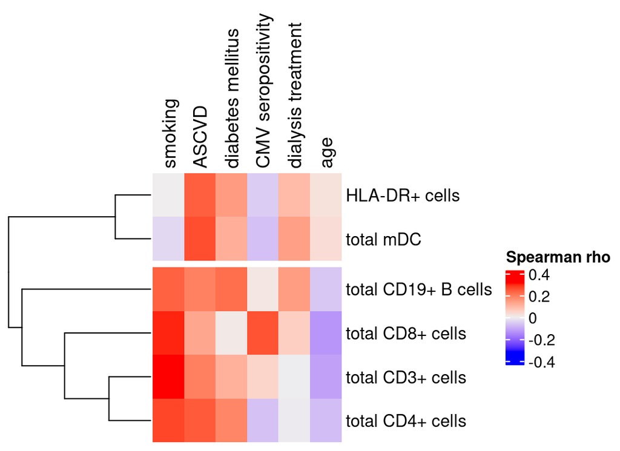

Spearman rho correlation between selected clinical characteristics and counts of borader categories of lymphocyte sub-populations. Dendrogram shows correlated sub-populations, based on UPGMA clustering

```r
set.seed(483)
# Prepare table
data_matrix <- data_clinical %>%
  dplyr::left_join(data_lymphocytes_general, by = 'id') %>%
  dplyr::select(-id) %>%
  cor(method = 'spearman') %>%
  data.frame() %>%
  dplyr::filter(
    row.names(.) %in% colnames(data_lymphocytes_general)[-1]
    ) %>%
  dplyr::select(
    row.names(perm_specific_multivariable_sequential)[1:5],
    dialysis
    ) %>% as.matrix()

colnames(data_matrix)[1] <- 'smoking'
colnames(data_matrix)[2] <- 'CMV seropositivity'
colnames(data_matrix)[6] <- 'dialysis treatment'
colnames(data_matrix)[5] <- 'age'
colnames(data_matrix)[4] <- 'diabetes mellitus'

# Calculate distance and perform hierarchical clustering
distance_matrix2 <- dist(t(outcomes_gen))
hc2 <- hclust(distance_matrix2, method = 'average')

col_fun = colorRamp2(c(-0.5, 0, 0.5), c("blue", "white", "red"))

# Heatmap

tr <- Heatmap(data_matrix,
        name = "Spearman rho",
        cluster_rows = hc2,
        show_row_dend = TRUE,
        show_column_dend = FALSE,
        row_names_gp = gpar(fontsize = 11),
        column_names_side = "top",
        row_dend_width = unit(3.2, "cm"),
        row_split = 2,
        gap = unit(1.5, "mm"),
        row_title = NULL,
        column_title = NULL,
        row_title_rot = 0,
        row_title_gp = gpar(fontsize = 14))

print(tr)
```

```r
pdf("gitignore/figures/heatmap_general.pdf", width = 5.5, height = 4)
print(tr)
dev.off()
## png
##   2
```

### 3.4.2 Specific

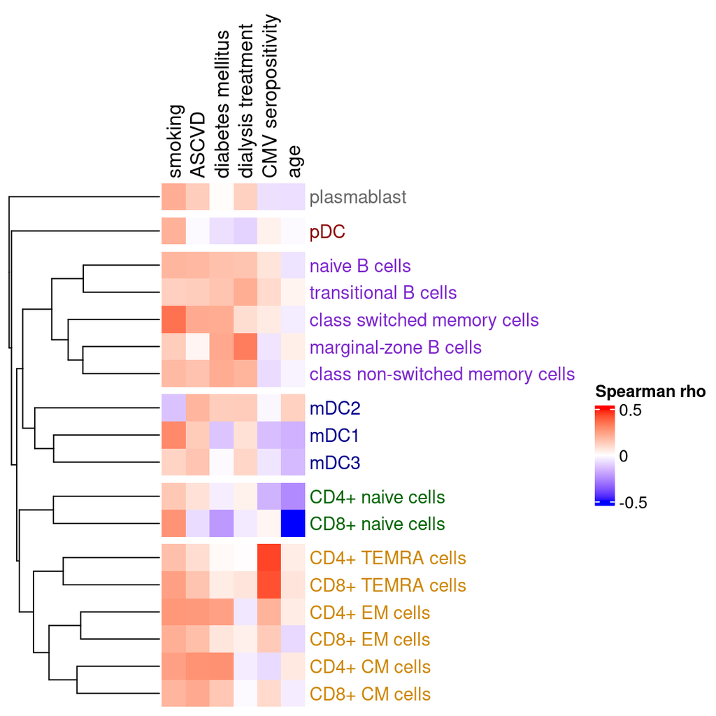

Matrix of Spearman correlation coefficients between clinical characteristics and counts of various peripheral blood immune cell subpopulations. The dendrogram illustrates similarities in cell counts, where closely linked tips indicate that the associated lymphocyte subpopulations are interrelated, with higher counts tending to co-occur. Correlations with an entire lymphocyte cluster suggest a specific influence (e.g., CMV infection), while correlations with individual subpopulations across different clusters indicate a more diffuse effect (e.g., smoking). The dendrogram is constructed using the unweighted pair group method with arithmetic mean (UPGMA) clustering. Clusters of subpopulations (as defined by UPGMA) are as follows: (1, grey) plasmablast; (2, red) plasmacytoid dendritic cells (pDC); (3, purple) B cells – including naive B cells, transitional B cells, class-switched memory cells, marginal-zone B cells, and class non-switched memory cells; (4, blue) myeloid dendritic cells (mDC1, mDC2, mDC3); (5, green) naive T cells – CD4+ and CD8+; and (6, orange) memory T cells – including CD4+ and CD8+ TEMRA, effector memory (EM), and central memory (CM) subsets.

```r
# Prepare table
set.seed(483)
data_matrix <- data_clinical %>%
  dplyr::left_join(data_lymphocytes_specific, by = 'id') %>%
  dplyr::select(-id) %>%
  cor(method = 'spearman') %>%
  data.frame() %>%
  dplyr::filter(
    row.names(.) %in% colnames(data_lymphocytes_specific)[-1]
    ) %>%
  dplyr::select(
    row.names(perm_specific_multivariable_sequential)[1:5],
    dialysis
    ) %>% as.matrix()


colnames(data_matrix)[1] <- 'smoking'
colnames(data_matrix)[2] <- 'CMV seropositivity'
colnames(data_matrix)[6] <- 'dialysis treatment'
colnames(data_matrix)[5] <- 'age'
colnames(data_matrix)[4] <- 'diabetes mellitus'


## define outcomes as all speficif features
outcomes <- data_lymphocytes_specific_log10 %>%
  dplyr::select(-id)

# Calculate distance and perform hierarchical clustering
distance_matrix2 <- dist(t(outcomes))
hc2 <- hclust(distance_matrix2, method = 'average')

cluster_assignment <- cutree(hc2, k = 6)

  # Assign colors per cluster
cluster_colors <- c("darkblue", "red4", "darkgreen", "grey40", "orange3", "purple3")
cluster_colors <- c("darkblue", "red4", "purple3", "grey40", "orange3", "darkgreen")

# Map colors to rows based on cluster
label_colors <- cluster_colors[cluster_assignment]

tr <- Heatmap(data_matrix,
        name = "Spearman rho",
        cluster_rows = hc2,
        show_row_dend = TRUE,
        show_column_dend = FALSE,
        row_names_gp = gpar(fontsize = 11, col = label_colors),
        column_names_side = "top",
        row_dend_width = unit(3.2, "cm"),
        row_split = 6,
        gap = unit(1.5, "mm"),
        row_title = NULL,
        column_title = NULL,
        row_title_rot = 0,
        row_title_side = c("right"),
        row_title_gp = gpar(fontsize = 14, col = label_colors),
        col = col_fun)

print(tr)
```

```r
pdf("gitignore/figures/heatmap_specific.pdf", width = 6, height = 6)
tr
dev.off()
## png
##   2
```